# Lecture 5 Exercises

Resampling Methods

# Exercise 1 - The Validation Set Approach

```r
library(ISLR)
library(boot)
```

The Auto data set is contained in the ISLR package

```r
str(Auto)
```

```
'data.frame':   392 obs. of  9 variables:
 $ mpg         : num  18 15 18 16 17 15 14 14 14 15 ...
 $ cylinders   : num  8 8 8 8 8 8 8 8 8 8 ...
 $ displacement: num  307 350 318 304 302 429 454 440 455 390 ...
 $ horsepower  : num  130 165 150 150 140 198 220 215 225 190 ...
 $ weight      : num  3504 3693 3436 3433 3449 ...
 $ acceleration: num  12 11.5 11 12 10.5 10 9 8.5 10 8.5 ...
 $ year        : num  70 70 70 70 70 70 70 70 70 70 ...
 $ origin      : num  1 1 1 1 1 1 1 1 1 1 ...
 $ name        : Factor w/ 304 levels "amc ambassador brougham",..: 49 36 231 14 161 141 54 223 241 2 ...
```

```r
attach(Auto)
```

Define training and test data

```r
set.seed(1)
(train=sample(nrow(Auto)/2)) # generate indices of a training data set by random sampling half of the observation indices of Auto
```

```
  [1]  68 167 129 162  43  14 187  51  85  21 106 182  74   7  73
 [16]  79  37 105 110 165  34 186 126  89 172  33  84 163  70 184
 [31]  42 111 148 156  20  44 121  87 168 160  40  25 119 122  39
 [46] 166 134  24 191 130  45  22 115 104 158 142 143 103  75  13
 [61] 169 173  23 178 170 139  29 108  48 171 146 190  31 102  17
 [76] 185 131 159  83 114  90 128 107  64  94 175  96 120  60 189
 [91]  93 176  10   1 192  59  26  15  58 147 149 151 144  76 152
[106] 133  53  86 136 118  35 123 109  97  78 145 141  28 180  61
[121]  46  67  71 117 161  49 194  56 195  50 183 193  57  91 157
[136] 116  16  19  36   2 112 132  72  92  41 137 100 179 113 101
[151] 153 196  11 124 135  95  47  54  80   9 181  63 140  99  65
[166]   5 155 188  66 154  12 164   6  32  38 127  69  55   3  82
[181]  52  88   4  27 177  77  62   8  30 125  98 174  81 138  18
[196] 150
```

```r
AutoTrain <- Auto[train,] # training data
AutoTest<- Auto[-train,] # test data
```

Fit 3 different regression models to the training data: Which model gives a better fit?

```r
(lm.fit <- lm(mpg~horsepower, data = AutoTrain)) # linear regression
```

```
Call:
lm(formula = mpg ~ horsepower, data = AutoTrain)

Coefficients:
(Intercept)   horsepower
     32.359       -0.109
```

```r
(lm.fit2 <- lm(mpg~poly(horsepower,2), data = AutoTrain)) # quadratic regression
```

```
Call:
lm(formula = mpg ~ poly(horsepower, 2), data = AutoTrain)

Coefficients:
         (Intercept)  poly(horsepower, 2)1
               19.69                -66.40
poly(horsepower, 2)2
               22.19
```

```r
(lm.fit3 <- lm(mpg~poly(horsepower,3), data = AutoTrain)) # cubic regression
```

```
Call:
lm(formula = mpg ~ poly(horsepower, 3), data = AutoTrain)

Coefficients:
         (Intercept)  poly(horsepower, 3)1
              19.686               -66.398
poly(horsepower, 3)2  poly(horsepower, 3)3
              22.190                 4.207
```

Pot the fits

```r
plot(mpg~horsepower, data = AutoTrain)
abline(lm.fit$coefficients, col="blue4") # plot linear fit
```

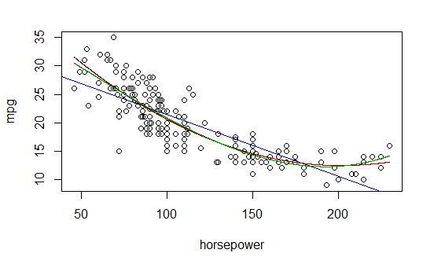

```r
x <- with(Auto, seq(min(horsepower), max(horsepower), length.out = 2000)) # define x values to plot polynomial fits

y2 <- predict(lm.fit2, newdata = data.frame(horsepower=x)) # corresponding predicted values
lines(x, y2, col = "red4")

y3 <- predict(lm.fit3, newdata = data.frame(horsepower = x)) # corresponding predicted values
lines(x, y3, col = "green4")
```

Looking at the plots, I think the quadratic (red line) will evaluate the best because it turns upwards less as horsepower increases.

## Calculate the test MSEs of the 3 models (mean of squared errors on test set)

```r
(MSE <- mean((mpg-predict(lm.fit,Auto))[-train]^2))
```

```
[1] 55.86116
```

```r
(MSE2 <- mean((mpg-predict(lm.fit2,Auto))[-train]^2))
```

```
[1] 46.08881
```

```r
(MSE3 <- mean((mpg-predict(lm.fit3,Auto))[-train]^2))
```

```
[1] 46.85124
```

I was right that fit2 is the best.

## Resample with a different training set

To get a different training set, we change the seed.

```r
set.seed(2)
(train=sample(nrow(Auto),nrow(Auto)/2)) # generate indices of a training data set by random sampling half of the observation indices of Auto
```

```
  [1] 341 198 262 273 349 204 381 297 178  75 131 306 371 311  63
 [16] 136 231 289  54 361 112 171  38 373 110 144  45 238 208 134
 [31] 339   9 350 130 244   3 129 304 385 301 375 274   8 164  37
 [46] 226 149 205 327 242  44 276 156 369 106 175 386 326 182 224
 [61] 271  13 328 189  96 166 265  53 143  36  17 241  80 127 267
 [76]  79  78 387 153 192  23  28   1 196 185 221 102 151  71 275
 [91] 293 212 239 269 133 154 163  91 225 191 142  25 383 197 370
[106] 310 172 377  94  34  72  77  81 176 376  29  51 200 277  82
[121] 353 109  12 222 364 374  76 195 325 229 343 337 330 118 296
[136] 180 107   2 247  14  98 213  56 299 266 124 295 139  62  35
[151]  86 217 316  88  70  89  95 150 103  43  16 363 216 288 332
[166] 249 358  11  50 108 155 278  42 135 146 360  87 323 193 100
[181] 138  67 177 240 169 145 257 141 184 354 186 294 384 256 181
[196] 357
```

```r
AutoTrain <- Auto[train,] # training data
AutoTest <- Auto[-train,] # test data

(lm.fit = lm(mpg~horsepower,data=AutoTrain)) # linear regression
```

```
Call:
lm(formula = mpg ~ horsepower, data = AutoTrain)

Coefficients:
(Intercept)   horsepower
    39.0280      -0.1513
```

```r
(lm.fit2 = lm(mpg~poly(horsepower,2),data=AutoTrain)) # quadratic regression
```

```
Call:
lm(formula = mpg ~ poly(horsepower, 2), data = AutoTrain)

Coefficients:
         (Intercept)  poly(horsepower, 2)1
               23.09                -84.77
poly(horsepower, 2)2
               29.98
```

```r
(lm.fit3=lm(mpg~poly(horsepower,3),data=Auto,subset=train)) # cubic regression
```

```
Call:
lm(formula = mpg ~ poly(horsepower, 3), data = Auto, subset = train)

Coefficients:
         (Intercept)  poly(horsepower, 3)1
              23.120              -118.289
poly(horsepower, 3)2  poly(horsepower, 3)3
              41.862                -4.145
```

```r
(MSE <- mean((mpg-predict(lm.fit,Auto))[-train]^2))
```

```
[1] 25.72651
```

```r
(MSE2 <- mean((mpg-predict(lm.fit2,Auto))[-train]^2))
```

```
[1] 20.43036
```

```r
(MSE3 <- mean((mpg-predict(lm.fit3,Auto))[-train]^2))
```

```
[1] 20.38533
```

```r
set.seed(3)
(train=sample(nrow(Auto),nrow(Auto)/2)) # generate indices of a training data set by random sampling half of the observation indices of Auto
```

```
  [1] 261 186 140  36 391 363 276 330 183 168  48 104 136  37 108
 [16] 392 165 137 256 274  12  40  22  70 296  15 385  75  29 343
 [31] 131  62 127 101 247 182 380 138  68  33 275 166 185 237 192
 [46] 388  65   9 241 105 197 128 198 317 171 389 334  73 195 204
 [61]  50 145 176 164 351 225 258 117  88 358  71 266 102 302  19
 [76]  47 161  66 245 303 139 218 361   4  16 325 262 308  99 390
 [91] 123 364  10  28 350  91 114 265 312 367 233 206   7 331 222
[106] 109 252 347 232 345  55 259 372 193 112  44 353  53  13 110
[121]  14 374  85 179 163 271 205 113 228 170   8 326 318 201  74
[136]  49 151 337 253  35 307 320 125 309 323   2 100 371 324 329
[151]  84  90 319 321 153 349 211 341 217 369 208  67 162 286 300
[166] 288  52  45 332 240 315 386 189  63 142 106 381 122 306 368
[181] 305  87 121   6 284 355  81 314 207  39 147 311 169 255 277
[196] 209
```

```r
AutoTrain <- Auto[train,] # training data
AutoTest <- Auto[-train,] # test data

(lm.fit = lm(mpg~horsepower,data=AutoTrain)) # linear regression
```

```
Call:
lm(formula = mpg ~ horsepower, data = AutoTrain)

Coefficients:
(Intercept)   horsepower
    40.0778      -0.1563
```

```r
(lm.fit2 = lm(mpg~poly(horsepower,2),data=AutoTrain)) # quadratic regression
```

```
Call:
lm(formula = mpg ~ poly(horsepower, 2), data = AutoTrain)

Coefficients:
         (Intercept)  poly(horsepower, 2)1
               23.54                -88.46
poly(horsepower, 2)2
               33.47
```

```r
(lm.fit3=lm(mpg~poly(horsepower,3),data=Auto,subset=train)) # cubic regression
```

```
Call:
lm(formula = mpg ~ poly(horsepower, 3), data = Auto, subset = train)

Coefficients:
         (Intercept)  poly(horsepower, 3)1
              23.620              -121.892
poly(horsepower, 3)2  poly(horsepower, 3)3
              46.112                -5.547
```

```r
(MSE <- mean((mpg-predict(lm.fit,Auto))[-train]^2))
```

```
[1] 21.99239
```

```r
(MSE2 <- mean((mpg-predict(lm.fit2,Auto))[-train]^2))
```

```
[1] 17.70254
```

```r
(MSE3 <- mean((mpg-predict(lm.fit3,Auto))[-train]^2))
```

```
[1] 17.71032
```

```r
set.seed(4)
(train=sample(nrow(Auto),nrow(Auto)/2)) # generate indices of a training data set by random sampling half of the observation indices of Auto
```

```
  [1]  75 307 259  71 172 371 245 186 391 312  62 102 130 152  84
 [16] 255 235 291 365  48 176 357 303 300 197 150 320  54 203  80
 [31] 180  65 304 379 246 315 288 316 126 354  76  61 133 234 373
 [46] 200 250 128 299 158  22 251 267  26 278 113 191 228 258 375
 [61] 177 119  21 350 321 225 360  52  79 268 356  78 308 125  45
 [76]  82  53 190  43 122  50 329 161  59 257 337 141  35 331 261
 [91]  41 196 359  36  73 147 336  87 282   9 302 179 227 121 185
[106] 165 352  98 353  25 332 159 138 127 139 218 269 192 211 285
[121] 270  46 276  47 213 305 355   4  10 215 256  69  95  90 362
[136] 367 116 364 387 388 222 204 209  30 193 342 273 338 145 374
[151] 313 271 181 358 348   2 306 104 349 277 175 384 173 254 111
[166] 274 162 155  51 281 238 361 240 383 310 226  93 108 372 385
[181] 325  94   8 363 284 231  63 318  14 132 129 262 386 171 223
[196] 237
```

```r
AutoTrain <- Auto[train,] # training data
AutoTest <- Auto[-train,] # test data

(lm.fit = lm(mpg~horsepower,data=AutoTrain)) # linear regression
```

```
Call:
lm(formula = mpg ~ horsepower, data = AutoTrain)

Coefficients:
(Intercept)   horsepower
    38.4897      -0.1435
```

```r
(lm.fit2 = lm(mpg~poly(horsepower,2),data=AutoTrain)) # quadratic regression
```

```
Call:
lm(formula = mpg ~ poly(horsepower, 2), data = AutoTrain)

Coefficients:
         (Intercept)  poly(horsepower, 2)1
               23.60                -76.12
poly(horsepower, 2)2
               31.86
```

```r
(lm.fit3=lm(mpg~poly(horsepower,3),data=Auto,subset=train)) # cubic regression
```

```
Call:
lm(formula = mpg ~ poly(horsepower, 3), data = Auto, subset = train)

Coefficients:
         (Intercept)  poly(horsepower, 3)1
              23.543              -116.622
poly(horsepower, 3)2  poly(horsepower, 3)3
              43.443                -4.689
```

```r
(MSE <- mean((mpg-predict(lm.fit,Auto))[-train]^2))
```

```
[1] 24.31623
```

```r
(MSE2 <- mean((mpg-predict(lm.fit2,Auto))[-train]^2))
```

```
[1] 19.02516
```

```r
(MSE3 <- mean((mpg-predict(lm.fit3,Auto))[-train]^2))
```

```
[1] 19.02982
```

```r
set.seed(5)
(train=sample(nrow(Auto),nrow(Auto)/2)) # generate indices of a training data set by random sampling half of the observation indices of Auto
```

```
  [1] 322 363 185 207 203 377 297 213 222  71 294 314 309 332  16
 [16] 128  27 220 330  85 122 307 113 184  92 269 235  54 146 192
 [31] 153 298 116 248   8 375 104 236 123 326 149  91  72  51  80
 [46] 358 379 316  90 127 225  15 100 209 148 125 242 139 137   4
 [61]   3 155 227 333 376 240 169 130 272 188   9 233 256 145 262
 [76]  61 135 152 356 323 331  17 206 176 141  28 329 343 295  62
 [91] 191 268 324 159 349 362 154  87  63  58 224  68 110 312  30
[106]  67  25 216  69 264  50 163 223  35  21 239 243 195  43 317
[121] 387 305 384  84 371  37 286 118 261 385  81 204  26 304 370
[136] 386 177 389 156  56 111 161 219 380 107 351 112 369 102 247
[151] 121 325 138  18  40 285 124   2 237 205  99 253  49 365 254
[166] 162 327 210  34 115  73 179  33 308 336 390 101  88 170 189
[181] 126   5 173  57  13  55 328 334   1  79  66 374 320  83 119
[196] 355
```

```r
AutoTrain <- Auto[train,] # training data
AutoTest <- Auto[-train,] # test data

(lm.fit = lm(mpg~horsepower,data=AutoTrain)) # linear regression
```

```
Call:
lm(formula = mpg ~ horsepower, data = AutoTrain)

Coefficients:
(Intercept)   horsepower
    40.4769      -0.1627
```

```r
(lm.fit2 = lm(mpg~poly(horsepower,2),data=AutoTrain)) # quadratic regression
```

```
Call:
lm(formula = mpg ~ poly(horsepower, 2), data = AutoTrain)

Coefficients:
         (Intercept)  poly(horsepower, 2)1
               23.45                -86.04
poly(horsepower, 2)2
               33.38
```

```r
(lm.fit3=lm(mpg~poly(horsepower,3),data=Auto,subset=train)) # cubic regression
```

```
Call:
lm(formula = mpg ~ poly(horsepower, 3), data = Auto, subset = train)

Coefficients:
         (Intercept)  poly(horsepower, 3)1
               23.58               -125.32
poly(horsepower, 3)2  poly(horsepower, 3)3
               47.72                 -8.40
```

```r
(MSE <- mean((mpg-predict(lm.fit,Auto))[-train]^2))
```

```
[1] 20.88794
```

```r
(MSE2 <- mean((mpg-predict(lm.fit2,Auto))[-train]^2))
```

```
[1] 16.79876
```

```r
(MSE3 <- mean((mpg-predict(lm.fit3,Auto))[-train]^2))
```

```
[1] 17.02604
```

fit2 and 3 were always close, and it wasn’t the case that fit2 always won.

# Exercise 1.1

Now lets draw a nice graph that compares the results with different training data sets

```r
  # Draw graph for 1 training sample

  MSE <- rep(0,10) # initialising the MSE vector (we will need it below when we add )

  set.seed(1) # initialize the randomizer with a different number
  train <- sample(nrow(Auto),nrow(Auto)/2) # generate indices of a training data set by random sampling half of the observation indices of Auto
  AutoTrain <- Auto[train,] # training data
  AutoTest <- Auto[-train,] # test data
  for (i in 1:10){
    lm.fit=lm(mpg~poly(horsepower,i),data=AutoTrain)
    MSE[i] <- mean((mpg-predict(lm.fit,Auto))[-train]^2)
  }

  x <- seq(1,10,1)
  plot(MSE~x, col=rainbow(1)[1], ylim=c(-2,30))
  lines(MSE~x, col=rainbow(1)[1])
```

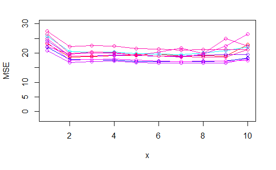

```r
  # Add graphs for different training samples
  for (j in 2:10){
    set.seed(j) # initialize the randomizer with different numbers
    train <- sample(nrow(Auto),nrow(Auto)/2) # generate indices of a training data set by random sampling half of the observation indices of Auto
    AutoTrain <- Auto[train,] # training data
    AutoTest <- Auto[-train,] # test data
    for (i in 1:10){
      lm.fit=lm(mpg~poly(horsepower,i),data=AutoTrain)
      MSE[i] <- mean((mpg-predict(lm.fit,Auto))[-train]^2)
  }

  points(MSE~x, col=rainbow(j)[j]) # add to the previous plot
  lines(MSE~x, col=rainbow(j)[j])

}
```

# Validation Set Approach (VSA)

*Advantages* 1. Simple 2. Easy to implement

*Disadvantages* *1. High varaince (low stability)* on some data sets. *2. High bias* on some data sets: since the training data is only a part of our sample, the VSA tends to overestimate the test error. We would prefer to train our model on the whole sample because statistical methods tend to perorm better the more observations they can use to learn.

# Exercise 2 - Leave-One_out Cross-Validation (LOOCV)

The LOOCV estimate can be automatically computed for any generalized linear model using the glm() together with the cv.glm() function. We‘ve used the glm() before for logistic regression by passing in the family=“binomial” argument. But if we use glm() to fit a model without passing in the family argument, then it performs linear regression, just like the lm() function.

```r
glm.fit <- glm(mpg~horsepower, data=Auto)
coef(glm.fit)
```

```
(Intercept)  horsepower
 39.9358610  -0.1578447
```

```r
lm.fit <- lm(mpg~horsepower, data = Auto)
coef(lm.fit)
```

```
(Intercept)  horsepower
 39.9358610  -0.1578447
```

Both give the same values

Without specifying “family” as a parameter, glm() falls back to linear regression. We use it here because it comes with a function for cross-validation.

```r
glm.fit <- glm(mpg~horsepower, data = Auto)

cv.err <- cv.glm(Auto,glm.fit) # computing the LOOCV prediction error. If we don't set the parameter K, cv.glm defaults to LOOCV
cv.err$delta[1] # the estimate for the test error is stored in delta[1]
```

```
[1] 24.23151
```

Now we calculate the LOOC test error for polynomial regression models of degree 1, …, 10. It takes a bit to evaluate.

```r
cv.error <- rep(0,10) # initialising the LOOCV error vector
for (i in 1:10){
  glm.fit <- glm(mpg~poly(horsepower,i), data = Auto)
  cv.error[i] <- cv.glm(Auto,glm.fit)$delta[1]
}
cv.error
```

```
 [1] 24.23151 19.24821 19.33498 19.42443 19.03321 18.97864
 [7] 18.83305 18.96115 19.06863 19.49093
```

Plot the results

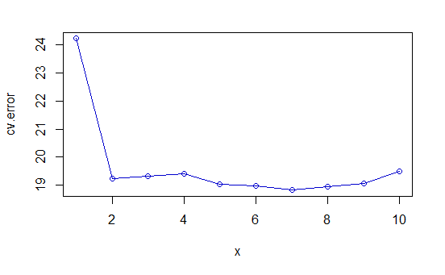

```r
x<- seq(1,10,1)
plot(cv.error~x, col="blue3")
lines(cv.error~x, col="blue3")
```

# Exercise 3

```r
set.seed(17)
```

Now we calculate the k-fold CV test error for polynomial regression models of degree 1,…,10. Notice that the computation time is much shorter than that of LOOCV.

```r
cv.error.10=rep(0,10)
for (i in 1:10){
  glm.fit = glm(mpg~poly(horsepower,i),data=Auto)
  cv.error.10[i] = cv.glm(Auto,glm.fit,K=10)$delta[1] # Setting K=10 means 10-fold CV
}
cv.error.10
```

```
 [1] 24.27207 19.26909 19.34805 19.29496 19.03198 18.89781
 [7] 19.12061 19.14666 18.87013 20.95520
```

Plot the results

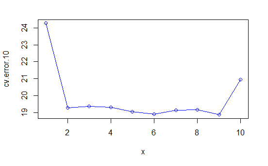

```r
plot(cv.error.10~x, col="blue")
lines(cv.error.10~x, col="blue")
```

# Exercise 3.1

Add graphs for different training samples

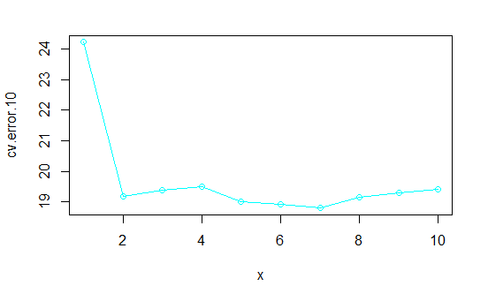

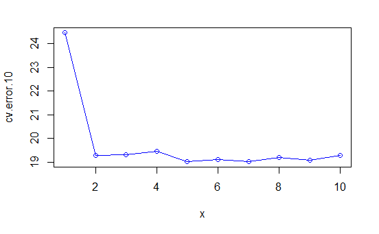

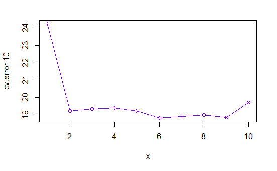

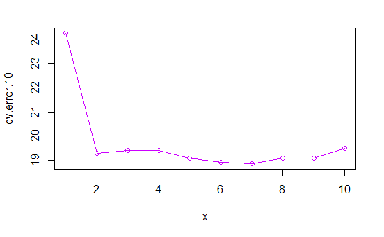

```r
for (j in 2:5){
  set.seed(j) # initialize the randomizer with different numbers
  for (i in 1:10){
    glm.fit=glm(mpg~poly(horsepower,i),data=Auto)
    cv.error.10[i]=cv.glm(Auto, glm.fit, K=19)$delta[1] # Settling K=10 means 10-fold CD
  }
  plot(cv.error.10~x, col=rainbow(j)[j])
  lines(cv.error.10~x, col=rainbow(j)[j])
}
```

```r
NA
NA
NA
```